# Plotting Growth Curves

14 February, 2025

# 1 Introduction

The data that we are going to use for this exercise is published in the mBio paper (Niggli S 2023). It can be found online on: https://doi.org/10.6084/m9.figshare.23578086.v1 It describes the OD600 (growth) of the *Staphylococcus aureus* strain **JE2** in different media.

# 2 Reading in Data and Plotting Growth Curves

```r
fN <- "JE_growth_final.txt" # us this txt file that is copy pasted spread sheet from excel tab separated
dat <- read.table(fN, header = T, sep = "\t", stringsAsFactors = TRUE)
summary(dat)
```

```
##       Time       OD600_blank_corrected Strain     Growth_Medium   Replicate
##  Min.   : 0.00   Min.   :-0.00255      JE2:8220   NaCl:2740     Min.   :1.00
##  1st Qu.:12.00   1st Qu.: 0.52904                 SN  :2740     1st Qu.:1.75
##  Median :24.00   Median : 0.66369                 TSB :2740     Median :2.50
##  Mean   :24.21   Mean   : 0.62075                               Mean   :2.50
##  3rd Qu.:36.50   3rd Qu.: 0.84369                               3rd Qu.:3.25
##  Max.   :48.50   Max.   : 1.24148                               Max.   :4.00
##
##  Experiment
##  exp1:1164
##  exp2:1176
##  exp3:1176
##  exp4:1176
##  exp5:1176
##  exp6:1176
##  exp7:1176
```

```r
str(dat)
```

```
## 'data.frame':    8220 obs. of  6 variables:
##  $ Time                 : num  0 0.5 1 1.5 2 2.5 3 3.5 4 4.5 ...
##  $ OD600_blank_corrected: num  0.00055 0.00055 0.000425 0.00055 0.00065 ...
##  $ Strain               : Factor w/ 1 level "JE2": 1 1 1 1 1 1 1 1 1 1 ...
##  $ Growth_Medium        : Factor w/ 3 levels "NaCl","SN","TSB": 3 3 3 3 3 3 3 3 3 3 ...
##  $ Replicate            : int  1 1 1 1 1 1 1 1 1 1 ...
##  $ Experiment           : Factor w/ 7 levels "exp1","exp2",..: 1 1 1 1 1 1 1 1 1 1 ...
```

```r
# this print command is only shown on the html if include = TRUE
library(ggplot2)
dat1 <- dat[dat$Experiment == "exp1" & dat$Replicate == "1",]
plot <- ggplot(dat1, aes(x = Time, y = OD600_blank_corrected, color = Growth_Medium)) +
    geom_point(size = 0.3)
    labs(title = "Growth Curves: experiment1 & replicate1",
       x = "Time",
       y = "Population Size",
       color = "Growth Medium") +
  theme_minimal()
```

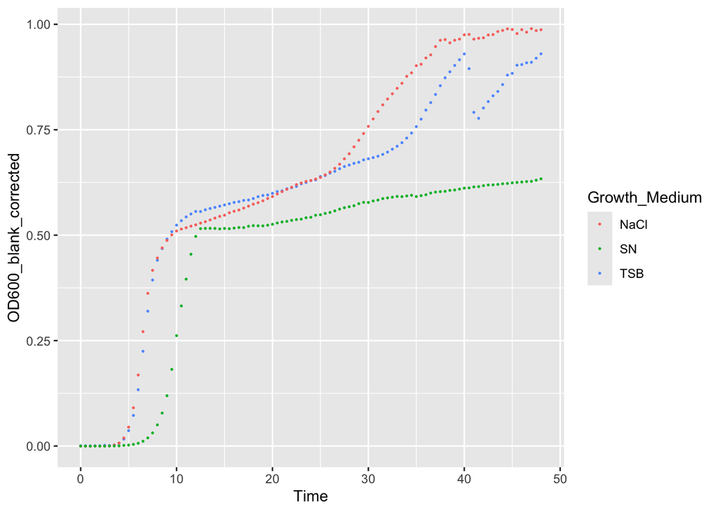

```r
print(plot)
```

The dimensions of this dataset are shown above. It is easy possible to show also content of variables in the html part.  
Note: if you end a line with 2 spaces you go to a new paragraph.

Like here: 8220, 6

# 3 Session Information

**R version 4.4.2 (2024-10-31)**

**Platform:** x86_64-apple-darwin20

**locale:** en_US.UTF-8||en_US.UTF-8||en_US.UTF-8||C||en_US.UTF-8||en_US.UTF-8

**attached base packages:** *stats*, *graphics*, *grDevices*, *utils*, *datasets*, *methods* and *base*

**other attached packages:** *ggplot2(v.3.5.1)* and *readr(v.2.1.5)*

**loaded via a namespace (and not attached):** *gtable(v.0.3.6)*, *jsonlite(v.1.8.9)*, *dplyr(v.1.1.4)*, *compiler(v.4.4.2)*, *Rcpp(v.1.0.14)*, *tidyselect(v.1.2.1)*, *jquerylib(v.0.1.4)*, *scales(v.1.3.0)*, *yaml(v.2.3.10)*, *fastmap(v.1.2.0)*, *R6(v.2.5.1)*, *labeling(v.0.4.3)*, *generics(v.0.1.3)*, *knitr(v.1.49)*, *tibble(v.3.2.1)*, *bookdown(v.0.42)*, *pander(v.0.6.5)*, *munsell(v.0.5.1)*, *bslib(v.0.9.0)*, *pillar(v.1.10.1)*, *tzdb(v.0.4.0)*, *rlang(v.1.1.5)*, *cachem(v.1.1.0)*, *xfun(v.0.50)*, *sass(v.0.4.9)*, *cli(v.3.6.3)*, *withr(v.3.0.2)*, *magrittr(v.2.0.3)*, *digest(v.0.6.37)*, *grid(v.4.4.2)*, *rstudioapi(v.0.17.1)*, *hms(v.1.1.3)*, *lifecycle(v.1.0.4)*, *vctrs(v.0.6.5)*, *evaluate(v.1.0.3)*, *glue(v.1.8.0)*, *farver(v.2.1.2)*, *colorspace(v.2.1-1)*, *rmarkdown(v.2.29)*, *tools(v.4.4.2)*, *pkgconfig(v.2.0.3)* and *htmltools(v.0.5.8.1)*

# References

Niggli S, Poveda L, Schwyter L. 2023. “Rapid and Strain-Specific Resistance Evolution of Staphylococcus Aureus Against Inhibitory Molecules Secreted by Pseudomonas Aeruginosa.” *mBio*. https://doi.org/10.1128/mbio.03153-22.